# Replacing Simulation with a Formula

Lesson 34 — Central Limit Theorem and t-statistics

Lt Col Cho

## Four distributions we’ve seen

| Distribution | Values plotted | Centered at | Can we see it in practice? |
| --- | --- | --- | --- |
| **Data** distribution | individual observations in one sample | $\bar{x}$ | Yes |
| **Sampling** distribution | a statistic (e.g., $\bar{x}$) from every possible sample of size $n$ | the parameter $\mu$ | No: requires many samples |
| **Bootstrap** distribution | the statistic from resamples of the one sample | the observed statistic | Yes, by simulation |
| **Null** distribution | the statistic from samples generated assuming $H_0$ | the null value | Yes, by simulation |

- The **standard error (SE)** of a statistic is the standard deviation of its sampling distribution.
- The bootstrap approximates the **spread and shape** of the sampling distribution.
- **Can we estimate the sampling distribution without simulation?**

## The Central Limit Theorem

If a sample consists of $n$ **independent** observations from a population with mean $\mu$ and standard deviation $\sigma$, and $n$ is **sufficiently large**, then the sampling distribution of $\bar{x}$ is approximately

$$\bar{x} \sim N\!\left(\text{mean} = \mu,\ \ \text{sd} = \frac{\sigma}{\sqrt{n}}\right)$$

**1. Shape**

Approximately Normal. The approximation improves as $n$ increases, whatever the shape of the population distribution.

**2. Center**

The population mean $\mu$.

**3. Spread**

Standard error $\sigma / \sqrt{n}$, which decreases as $n$ increases.

- The same result holds for a **proportion** $\hat{p}$ (the mean of a variable coded 0 and 1) and for **differences** of two means or two proportions.
- The CLT describes the distribution of **sample means**. The distribution of individual observations does not become Normal.

## The CLT for four statistics

- **Top:** four populations. **Bottom:** the statistic from 10,000 random samples of each population. Blue curves: the Normal distribution the CLT gives (center = parameter, SD = SE).

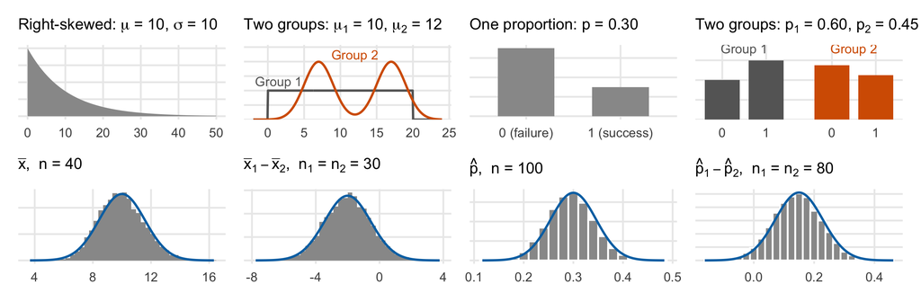

|  | $\bar{x}$ | $\bar{x}_1 - \bar{x}_2$ | $\hat{p}$ | $\hat{p}_1 - \hat{p}_2$ |
| --- | --- | --- | --- | --- |
| Parameter | 10 | -2 | 0.30 | 0.15 |
| Mean of the statistics | 9.98 | -1.99 | 0.300 | 0.150 |
| SD of the statistics | 1.57 | 1.44 | 0.046 | 0.079 |
| SE from the CLT | 1.58 | 1.44 | 0.046 | 0.078 |

## Conditions for the CLT

1. **Independence.** The observations are independent. A random sample or random assignment ensures this.
2. **Large enough sample.** What counts as “large enough” depends on the statistic:

| Statistic | Large enough when… |
| --- | --- |
| Proportion $\hat{p}$ | at least 10 expected successes and 10 expected failures: $np \geq 10$ and $n(1 - p) \geq 10$ |
| Mean $\bar{x}$ | small $n$: no clear outliers; large $n$: no particularly extreme outliers |
|  | guideline: slight skew is acceptable for $n = 15$, moderate skew for $n = 30$, strong skew for $n = 60$ |
| Differences | the condition holds in **each** group, and the groups are independent |

- $n \geq 30$ is a guideline, not a guarantee: for a population with extreme outliers, the sampling distribution of $\bar{x}$ can remain skewed at $n = 100$ or larger.

## The spread: standard error

- The **standard error (SE)** of a statistic is the standard deviation of its sampling distribution: the “spread” in the CLT.
- The CLT gives each SE in terms of population values, which are unknown, so we substitute sample values:

| Statistic | SE from the CLT | Estimated SE |
| --- | --- | --- |
| $\bar{x}$ | $\dfrac{\sigma}{\sqrt{n}}$ | $\dfrac{s}{\sqrt{n}}$ |
| $\hat{p}$ | $\sqrt{\dfrac{p(1-p)}{n}}$ | $\sqrt{\dfrac{\hat{p}(1-\hat{p})}{n}}$ |
| $\bar{x}_1 - \bar{x}_2$ | $\sqrt{\dfrac{\sigma_1^2}{n_1} + \dfrac{\sigma_2^2}{n_2}}$ | $\sqrt{\dfrac{s_1^2}{n_1} + \dfrac{s_2^2}{n_2}}$ |
| $\hat{p}_1 - \hat{p}_2$ | $\sqrt{\dfrac{p_1(1-p_1)}{n_1} + \dfrac{p_2(1-p_2)}{n_2}}$ | $\sqrt{\dfrac{\hat{p}_1(1-\hat{p}_1)}{n_1} + \dfrac{\hat{p}_2(1-\hat{p}_2)}{n_2}}$ |

- **Proportion:** the SE depends only on $p$. Under $H_0: p = p_0$ the SE is **known**: $\sqrt{p_0(1-p_0)/n}$.
- **Mean:** the SE depends on $\sigma$, which $H_0: \mu = \mu_0$ does not specify. The SE must be **estimated** with $s$.

## From the CLT to $Z$ and $T$

- **The CLT gives the null distribution of $\hat{p}$. How do we measure how far the observed $\hat{p}$ is from $p_0$?**
- Example: $H_0: p = 0.50$, $n = 100$, observed $\hat{p} = 0.58$. SE under $H_0$: $\sqrt{0.50 \cdot 0.50 / 100} = 0.05$.

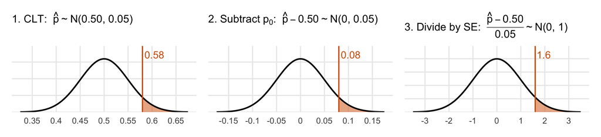

- Subtracting a constant shifts the axis, and dividing by a constant rescales it. The shape and the shaded area, $P(\hat{p} \geq 0.58) =$ 0.055, are the same in all three panels.
- After step 3, every test uses one reference distribution, $N(0, 1)$, and the value is the **number of SEs** between the statistic and the null value.
- Step 3 requires the SE. For $\hat{p}$, $H_0$ specifies $p_0$, so the SE is **known**: this gives $Z$. For $\bar{x}$, the SE is $\sigma/\sqrt{n}$ and $\sigma$ is unknown; replacing $\sigma$ with $s$ gives $T$.

## Standardizing with a known SE: $Z$

$$Z = \frac{\hat{p} - p_0}{\sqrt{p_0(1-p_0)/n}}
\qquad\qquad
Z \sim N(0, 1) \ \text{ approximately, if } H_0 \text{ is true}$$

- $\hat{p}$: the sample proportion. $p_0$: the value of $p$ stated in $H_0$ (the null value). $n$: the sample size.

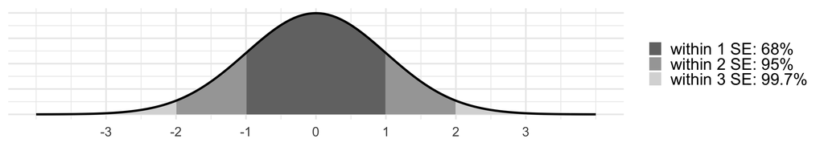

- $Z$ is the **number of standard errors** $\hat{p}$ lies above (positive) or below (negative) $p_0$: the Block 1 Z score, with the SE in place of the SD. Under $H_0$ the SE is **known**, and by the CLT $Z$ follows the **standard Normal** distribution. In R: `pnorm(z)` is the area to the **left** of $z$.

|  | $\hat{p}$ | $Z$ |
| --- | --- | --- |
| Name | test statistic | standardized statistic |
| Center under $H_0$ | $p_0$ | 0 |

## Standardizing with an estimated SE: $T$

$$T = \frac{\bar{x} - \mu_0}{s/\sqrt{n}}
\qquad\qquad
T \sim t_{n-1} \ \text{ approximately, if } H_0 \text{ is true}$$

- $\bar{x}$: the sample mean. $\mu_0$: the value of $\mu$ stated in $H_0$ (the null value). $s$: the sample SD. $n$: the sample size.

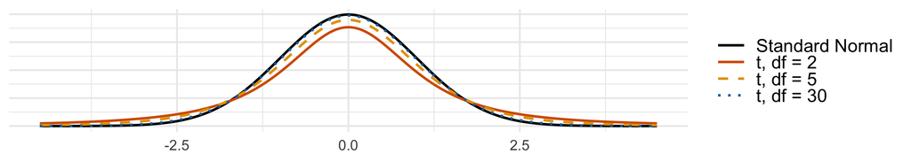

- $s$ varies from sample to sample, so $T$ varies more than $Z$. The **$t$-distribution** has heavier tails to account for that additional variability. One parameter: **degrees of freedom**, $df = n - 1$ for one mean ($t_{n-1}$ denotes $t$ with $df = n - 1$). As $df$ increases, $t$ approaches the standard Normal. In R: `pt(t, df)`.

|  | $Z$ | $T$ |
| --- | --- | --- |
| SE uses | a known value ($\sigma$ or $p_0$) | the sample SD $s$ |
| Used for | proportions | means (and regression slopes, Lesson 35) |

## Hypothesis tests with a mathematical model

- The four steps are unchanged. **Step 3** uses the Normal or $t$ curve instead of a simulated null distribution, and the p-value is the **area under the curve** at least as extreme as $Z$ or $T$.

| $H_0$ | Standardized statistic | Distribution under $H_0$ |
| --- | --- | --- |
| $\mu = \mu_0$ | $T = \dfrac{\bar{x} - \mu_0}{s/\sqrt{n}}$ | $t$, $df = n - 1$ |
| $p = p_0$ | $Z = \dfrac{\hat{p} - p_0}{\sqrt{p_0(1-p_0)/n}}$ | standard Normal |
| $\mu_1 - \mu_2 = 0$ | $T = \dfrac{(\bar{x}_1 - \bar{x}_2) - 0}{\sqrt{s_1^2/n_1 + s_2^2/n_2}}$ | $t$, $df = \min(n_1, n_2) - 1$ |
| $p_1 - p_2 = 0$ | $Z = \dfrac{(\hat{p}_1 - \hat{p}_2) - 0}{\sqrt{\hat{p}_{pool}(1-\hat{p}_{pool})\left(\frac{1}{n_1} + \frac{1}{n_2}\right)}}$ | standard Normal |

- Every row has the same form: (statistic − null value) / SE. The SE uses the null value wherever $H_0$ specifies one.

## One-mean $t$-test: gnome sleep

- **Claim:** gnomes sleep 145 minutes per night on average. A random sample of $n = 64$ USAFA gnomes has $\bar{x} = 135$ and $s = 16$ minutes. **Do USAFA gnomes sleep less on average?**

| Step |  |
| --- | --- |
| 0 | $\alpha = 0.05$ |
| 1 | $H_0: \mu = 145$ vs. $H_A: \mu < 145$ |
| 2 | Test statistic: $\bar{x} = 135$ |
| 3 | Conditions: random sample (independence); $n = 64$, no extreme outliers |
|  | $SE = \dfrac{s}{\sqrt{n}} = \dfrac{16}{\sqrt{64}} = 2$ |
|  | $T = \dfrac{135 - 145}{2} = -5$, with $df = n - 1 = 63$ |
|  | p-value $=$ `pt(-5, df = 63)` $= 2.4 \times 10^{-6}$ |

- **What does $T = -5$ mean? What would we have done with simulation?**

## Gnome sleep: the p-value as an area

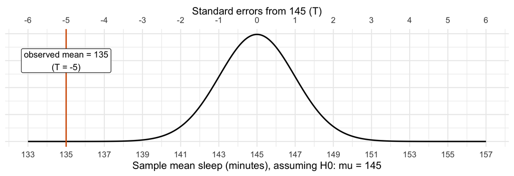

**Step 4:** p-value $< 0.001 < \alpha = 0.05$. Reject $H_0$: the data provide statistically discernible evidence that USAFA gnomes sleep less than 145 minutes per night on average.

## One-proportion $Z$-test: marijuana legalization

- A General Social Survey random sample of 1,563 US adults: 60% said marijuana should be legal. **Is the population proportion greater than 0.50?**

| Step |  |
| --- | --- |
| 0–1 | $\alpha = 0.05$; $H_0: p = 0.50$ vs. $H_A: p > 0.50$ |
| 2 | Test statistic: $\hat{p} = 0.60$ |
| 3 | Conditions: random sample; $np_0 = n(1 - p_0) = 781.5 \geq 10$ |
|  | $SE = \sqrt{\dfrac{p_0(1-p_0)}{n}} = \sqrt{\dfrac{0.5(0.5)}{1563}} = 0.01265$ (uses $p_0$: the test assumes $H_0$) |
|  | $Z = \dfrac{0.60 - 0.50}{0.01265} = 7.91$; p-value $=$ `pnorm(7.91, lower.tail = FALSE)` $< 0.001$ |
| 4 | Reject $H_0$: statistically discernible evidence that more than half of US adults think marijuana should be legal |

## When the Normal model does not fit

- A medical consultant: 3 of 62 clients had complications ($\hat{p} = 0.048$). Is the complication rate below the typical $p_0 = 0.10$?

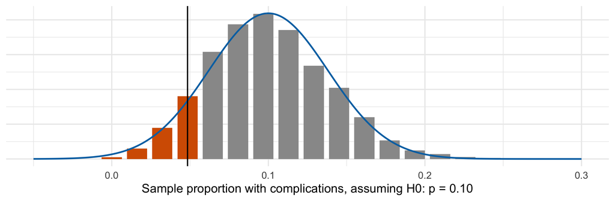

|  | Simulated null distribution | Normal model |
| --- | --- | --- |
| p-value | 0.123 | 0.088 |

- **Check the success-failure condition. Why do the two p-values differ?**

## Confidence intervals with a mathematical model

$$\text{point estimate} \pm \underbrace{(\text{critical value}) \times SE}_{\text{margin of error}}
\qquad \bar{x} \pm t^\star_{n-1}\frac{s}{\sqrt{n}} \qquad \hat{p} \pm z^\star\sqrt{\frac{\hat{p}(1-\hat{p})}{n}}$$

- The **critical value** is the number of SEs that captures the middle X% of the Normal ($z^\star$) or $t$ ($t^\star$) distribution. Use $t^\star$ for means and $z^\star$ for proportions.
- An interval has no null value, so a proportion’s SE uses $\hat{p}$.

| Confidence level | $z^\star$ (Normal) | $t^\star$, $df = 30$ |
| --- | --- | --- |
| 90% | 1.645 | 1.697 |
| 95% | 1.960 | 2.042 |
| 99% | 2.576 | 2.750 |

```r
qnorm(0.975)          # cutoff with 97.5% of the Normal curve below it
qt(0.975, df = 30)    # the same cutoff for t with 30 df
```

## Confidence intervals: gnome sleep

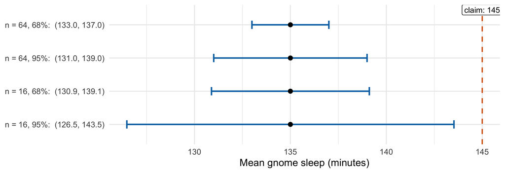

Gnomes: $\bar{x} = 135$ and $s = 16$ in both samples.

- **How do the intervals change with the confidence level? With the sample size? Is 145 plausible?**

## Confidence interval: marijuana legalization

- Marijuana survey: $\hat{p} = 0.60$, $n = 1,563$.

$$0.60 \pm 1.96\sqrt{\frac{0.60(0.40)}{1563}} = 0.60 \pm 1.96(0.0124) = (0.576,\ 0.624)$$

- The interval uses $\hat{p}$ in the standard error. The test used $p_0$, because the test assumes $H_0$; an interval has no null value.
- A headline states: “Majority of US adults think marijuana should be legalized.” **Does the interval support the headline?**
- **How would the interval change for a 99% confidence level? For a sample of 6,000 adults?**

## Simulation or mathematical model?

| Step | Simulation-based | Mathematical model-based |
| --- | --- | --- |
| 0–1. $\alpha$, hypotheses | same | same |
| 2. Observed statistic | same | same, plus its standardized value ($Z$ or $T$) |
| 3. Null distribution | simulate assuming $H_0$ | Normal or $t$ curve from the CLT |
| 3. p-value | proportion of simulated statistics at least as extreme | area under the curve beyond $Z$ or $T$ |
| 4. Conclusion | same | same |
| Confidence interval | middle X% of the bootstrap distribution | estimate $\pm$ critical value $\times$ SE |

- **Mathematical models:** no simulation and closed-form formulas, but only valid when the conditions hold, and available only for certain statistics (means, proportions, their differences, and regression coefficients).
- **Simulation:** works for other statistics (medians, standard deviations), but still requires independent observations and a representative sample.
- Neither method corrects biased sampling, confounding, or dependent observations.

## Practice: fuel efficiency

City fuel efficiency (mpg) for random samples of 2021 cars:

| Transmission | Mean | SD | $n$ |
| --- | --- | --- | --- |
| Manual | 22.7 | 4.58 | 25 |
| Automatic | 17.4 | 3.44 | 25 |

**Do the data provide statistically discernible evidence of a difference in mean city mileage? Use $\alpha = 0.05$.**

1. State $H_0$ and $H_A$.
2. Check the conditions.
3. Compute the test statistic, the standard error, and $T$. What degrees of freedom do you use?
4. Find the p-value with R and state a conclusion in context.

## Practice: working backwards

1. A 90% $t$-interval for a population mean, based on a random sample of 25 observations, is $(65, 77)$. Find the sample mean, the margin of error, and the sample standard deviation.
2. $H_0: \mu = 60$ vs. $H_A: \mu \neq 60$, with $s = 8$ and $n = 20$. For what sample mean(s) would the p-value equal 0.05?
3. Complete the sentence: as the sample size increases, the standard error ______ and the sampling distribution becomes ______.